# Joint Distribution

3/22/2020

Section 4.3

### Joint Distribution

Observe the value of 2 (or more) random variables and determine their joint probability structure.

**Example 1.** Roll a fair 4-sided die twice, record \( X \) as the outcome of the first roll and \( Y \) the outcome of the second.

The set of all possibilities is the **joint support** for \( (X,Y) \).

\[ \begin{aligned} (x, y) \in \{&(1,1), (1,2), (1,3), (1,4), \\ &... \\ &(4,1), (4,2), (4, 3), (4,4)\} \end{aligned} \]

## Bivariate Random Variable

*Definition.*

The ordered pair of random variables \( (X, Y) \) is a **bivariate random variable** (or random vector) if each \( X \) and \( Y \) associates a real number with every element of a sample space \( \Omega \).

We can extend this definition to *multivariate* rather than just bivariate.

## Joint pmf

*Definition.*

For \( X \) and \( Y \) both discrete random variables, the **joint probability mass function** (joint pmf, bivariate pmf) for \( (X,Y) \) is

\[ p(x,y) = P(X=x, Y=x) \]

### Bivariate Example

From Example 1, since the distribution is uniform, we can write the joint pmf as

\[ p(x,y) = \begin{cases} 1/16 & x,y \in \{1,2,3,4\} \\ 0 & else \end{cases} \]

It can also be important to graph the support of the probability distribution. Here, we graph the joint support.

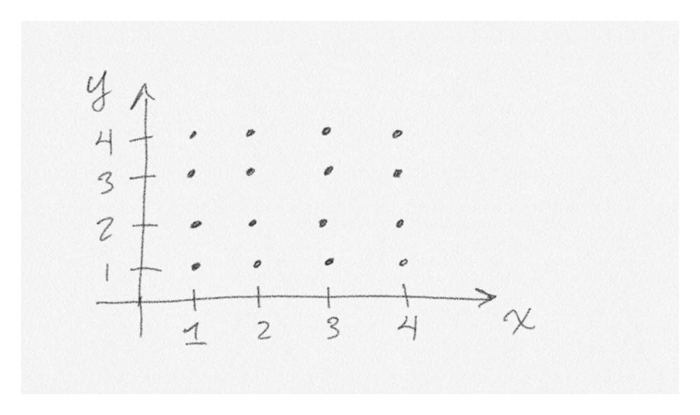

### Joint pmf Example

**Example 2.**

Roll a 6-sided fair die once, record as \( X \). What is the distribution and support of \( X \)?

\( X \sim Unif(S_X) \) where \( S_X = \{1, 2, ..., 6\} \).

Deal \( X \) cards from a standard deck and record \( Y \) the number of aces. What is the support of \( Y \)?

\[ S_Y = \begin{cases} 0, 1, ..., x & x < 4 \\ 0, 1, ..., 4 & x \geq 4 \end{cases} \]

### Example 2 Joint Support

This is certainly a different type of joint support. We can draw it out.

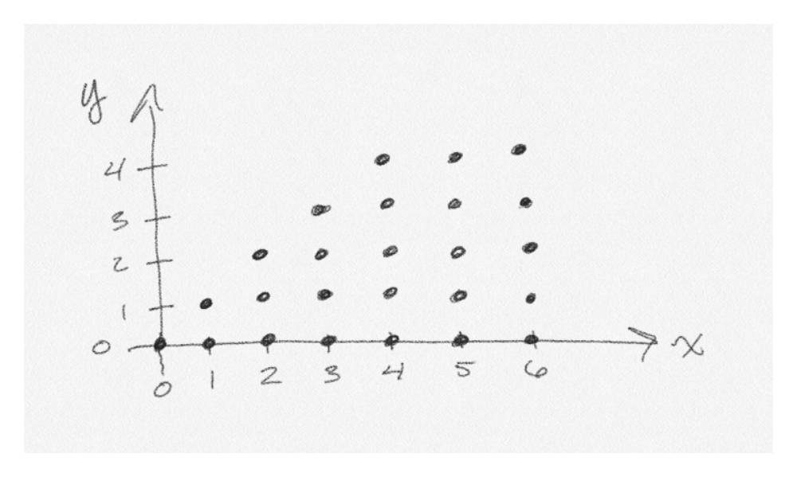

Observe that the support of the joint distribution is no longer the Cartesian product of the two random variables \( X \) and \( Y \). This is a necessary condition for Independence (see Section 4.4).

### Example 2 Joint pmf

How can we study the joint pmf for this problem?

We should first observe that we can calculate these probabilities by using condition. Observe,

\[ \small p(1,0) = P(X=1, Y=0) = P(Y=0|X=1)P(X=1) \]

Joint pmfs give the probabilities of observing the intersection of two random variable outcomes, thus we can apply our conditioning similar to Chapter 2.

We have defined \( X \) as a uniform distribution and so \( \small P(X=x) = 1/6 \) for \( \small x \in S_X \).

### Example 2 Joint pmf Continued

How do we find \( \small P(Y=0|X=1) \)?

Counting!

\[ \small P(Y=0|X=1) = \frac{{4 \choose 0}{48 \choose 1}}{{52 \choose 1}} \]

We can then find \( \small p(1,0) \).

\[ \small \begin{aligned} p(1,0) &= P(X=1, Y=0) \\ &= P(Y=0|X=1)P(X=1) \\ &= \frac{{4 \choose 0}{48 \choose 1}}{{52 \choose 1}}(1/6) = 2/13 \end{aligned} \]

### Example 2 Joint pmf Continued

Similarly \( \small p(1,1) \).

\[ \small \begin{aligned} p(1,1) &= P(X=1, Y=1) \\ &= P(Y=1|X=1)P(X=1) \\ &= \frac{{4 \choose 1}{48 \choose 0}}{{52 \choose 1}}(1/6) = 1/78 \end{aligned} \]

We could continue this for all possible \( (x,y) \) pairs.

### Example 2 Joint pmf

We may also at this stage be able recognize a generalization of the formula. We need to be clear about our support of \( Y \) though, since it depends on \( X \).

\[ \small \begin{aligned} P(X=x, Y=y) = \begin{cases} \frac{{4 \choose y}{48 \choose x-y}}{{52 \choose x}}(1/6) & \text{for } x = 1, 2, 3 \text{ and } y = 0, 1, ..., x \\ \frac{{4 \choose y}{48 \choose x-y}}{{52 \choose x}}(1/6) & \text{for } x = 4, 5, 6 \text{ and } y = 0, 1, ..., 4 \\ 0 & else \end{cases} \end{aligned} \]

The need to write it this way is because \( Y \) only depends on \( X \) for values of \( X \) less than 4. For all outcomes of \( X \) greater than 4, it is possible to see all outcomes of \( Y \), since there are only 4 aces in the deck.

## Marginal pmf

*Definition.*

For a bivariate random variable \( (X,Y) \) with joint pmf

\[ \small p_{X,Y}(x,y) = P(X=x, Y=y) \]

the **marginal probability mass function** for \( X \) is given by

\[ \small p_{X}(x) = P(X=x) = \sum_{y\in S_Y}p_{X,Y}(x,y) \]

Similarly, we can define the marginal pmf for \( Y \) by

\[ \small p_{Y}(y) = P(Y=y) = \sum_{x\in S_X}p_{X,Y}(x,y) \]

### Example 3 Marginal pmf

Let \( \small x \in \{1,2,3\} \) and \( \small x \in \{1,2,3\} \) be outcomes of the bivariate random variable \( \small (X,Y) \). The table below gives the joint pmf for this bivariate random variable.

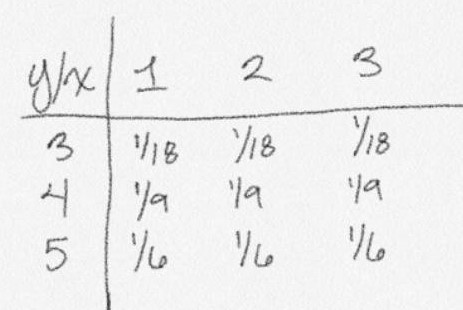

The table gives the probability of seeing each bivariate \( \small (x,y) \) pair. Thus, for example, observe \( \small p(1,5) = 1/6 \).

### Example 3 Marginal pmf

How do we get the marginal pmfs for \( X \) and \( Y \)?

Recall \( \small p_{X}(x) = P(X=x) = \sum_{y\in S_Y}p_{X,Y}(x,y) \). Thus, if we find all of the column sums, we obtain the marginal pmf for \( X \). If we find the row sums, we find the marginal pmf for \( Y \).

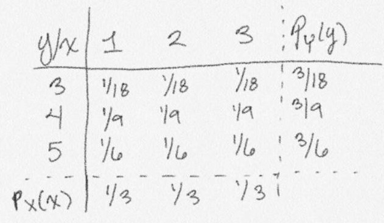

Observe that \( \small p_X(x) = 1/3 \) for each value of \( x \), thus we can say the marginal pmf of \( X \) is uniform. This is displayed as the 4th row. The 4th column gives the marginal pmf of \( Y \).

## Expectation of a function of two random variables

*Result.*

For \( \small f(x,y) \) a function of the pair of random variable \( \small (X,Y) \), the expected value of \( \small f(X,Y) \) is

\[ E[f(X,Y)] = \sum\limits_{x\in S_X} \sum\limits_{y\in S_y} f(x,y)P(X=x,Y=y) \]

### Example 3 Continued

Returning to the table given for Example 3, find the \( E[X-Y] \).

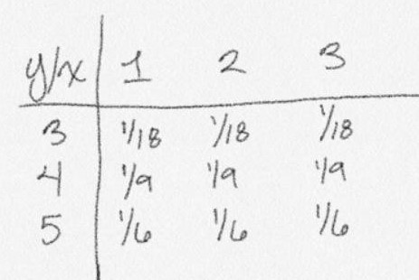

This is only tedious because we must calculate this over all \( (x,y) \) pairs.

\[ \small \begin{aligned} E[X-Y] &= \sum\limits_{x=1}^{3} \sum\limits_{y=3}^5 (x-y)P(X=x,Y=y) \\ &= (1-3)p(1,3) + (1-4)p(1,4) + (1-5)p(1,5) + ... + (3-5)p(3,5) \\ &= -2(1/18) - 3(1/9) - 4(1/6) - (1/18) - 2(1/9) \\ &\quad - 3(1/6) + 0 - (1/9) - 2(1/6) \\ &= -7/3 \approx -2.33 \end{aligned} \]